# DATA 621: Home Work 01

# Libraries

```r
library(knitr)
library(tidyverse)
library(reshape2)
library(VIM)
library(corrplot)
library(naniar)
```

# Data

In this homework assignment, we are asked to explore, analyze and model a baseball data set containing approximately 2200 records. Each record represents a professional baseball team from the years 1871 to 2006 inclusive. Each record has the performance of the team for the given year, with all of the statistics adjusted to match the performance of a 162 game season.

Our objective is to build a multiple linear regression model on the training data to predict the number of wins for the team based on the variables given or variables that derive from the variables provided. Below is a short description of the variables of interest in the data set:

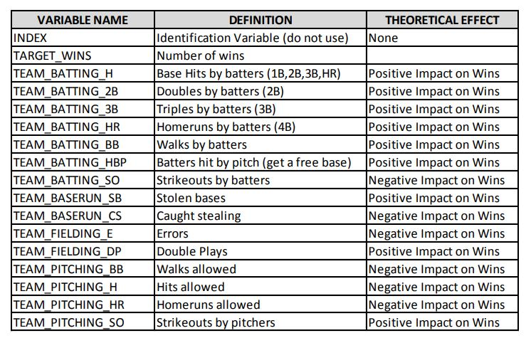

# Load Data

```r
train <- read.csv('./moneyball-training-data.csv')
test <- read.csv('./moneyball-evaluation-data.csv')

#Removing the index variable
train$INDEX <- NULL
test$INDEX <- NULL
```

```r
head(train)
```

```
##   TARGET_WINS TEAM_BATTING_H TEAM_BATTING_2B TEAM_BATTING_3B TEAM_BATTING_HR
## 1          39           1445             194              39              13
## 2          70           1339             219              22             190
## 3          86           1377             232              35             137
## 4          70           1387             209              38              96
## 5          82           1297             186              27             102
## 6          75           1279             200              36              92
##   TEAM_BATTING_BB TEAM_BATTING_SO TEAM_BASERUN_SB TEAM_BASERUN_CS
## 1             143             842              NA              NA
## 2             685            1075              37              28
## 3             602             917              46              27
## 4             451             922              43              30
## 5             472             920              49              39
## 6             443             973             107              59
##   TEAM_BATTING_HBP TEAM_PITCHING_H TEAM_PITCHING_HR TEAM_PITCHING_BB
## 1               NA            9364               84              927
## 2               NA            1347              191              689
## 3               NA            1377              137              602
## 4               NA            1396               97              454
## 5               NA            1297              102              472
## 6               NA            1279               92              443
##   TEAM_PITCHING_SO TEAM_FIELDING_E TEAM_FIELDING_DP
## 1             5456            1011               NA
## 2             1082             193              155
## 3              917             175              153
## 4              928             164              156
## 5              920             138              168
## 6              973             123              149
```

The train data set has 2276 records with 17 variables.

```r
str(train)
```

```
## 'data.frame':    2276 obs. of  16 variables:
##  $ TARGET_WINS     : int  39 70 86 70 82 75 80 85 86 76 ...
##  $ TEAM_BATTING_H  : int  1445 1339 1377 1387 1297 1279 1244 1273 1391 1271 ...
##  $ TEAM_BATTING_2B : int  194 219 232 209 186 200 179 171 197 213 ...
##  $ TEAM_BATTING_3B : int  39 22 35 38 27 36 54 37 40 18 ...
##  $ TEAM_BATTING_HR : int  13 190 137 96 102 92 122 115 114 96 ...
##  $ TEAM_BATTING_BB : int  143 685 602 451 472 443 525 456 447 441 ...
##  $ TEAM_BATTING_SO : int  842 1075 917 922 920 973 1062 1027 922 827 ...
##  $ TEAM_BASERUN_SB : int  NA 37 46 43 49 107 80 40 69 72 ...
##  $ TEAM_BASERUN_CS : int  NA 28 27 30 39 59 54 36 27 34 ...
##  $ TEAM_BATTING_HBP: int  NA NA NA NA NA NA NA NA NA NA ...
##  $ TEAM_PITCHING_H : int  9364 1347 1377 1396 1297 1279 1244 1281 1391 1271 ...
##  $ TEAM_PITCHING_HR: int  84 191 137 97 102 92 122 116 114 96 ...
##  $ TEAM_PITCHING_BB: int  927 689 602 454 472 443 525 459 447 441 ...
##  $ TEAM_PITCHING_SO: int  5456 1082 917 928 920 973 1062 1033 922 827 ...
##  $ TEAM_FIELDING_E : int  1011 193 175 164 138 123 136 112 127 131 ...
##  $ TEAM_FIELDING_DP: int  NA 155 153 156 168 149 186 136 169 159 ...
```

All the variables are integer and TEAM_BATTING_HBP has a lot of missing values. Let’s look at the summary of the data.

```r
summary(train)
```

```
##   TARGET_WINS     TEAM_BATTING_H TEAM_BATTING_2B TEAM_BATTING_3B
##  Min.   :  0.00   Min.   : 891   Min.   : 69.0   Min.   :  0.00
##  1st Qu.: 71.00   1st Qu.:1383   1st Qu.:208.0   1st Qu.: 34.00
##  Median : 82.00   Median :1454   Median :238.0   Median : 47.00
##  Mean   : 80.79   Mean   :1469   Mean   :241.2   Mean   : 55.25
##  3rd Qu.: 92.00   3rd Qu.:1537   3rd Qu.:273.0   3rd Qu.: 72.00
##  Max.   :146.00   Max.   :2554   Max.   :458.0   Max.   :223.00
##
##  TEAM_BATTING_HR  TEAM_BATTING_BB TEAM_BATTING_SO  TEAM_BASERUN_SB
##  Min.   :  0.00   Min.   :  0.0   Min.   :   0.0   Min.   :  0.0
##  1st Qu.: 42.00   1st Qu.:451.0   1st Qu.: 548.0   1st Qu.: 66.0
##  Median :102.00   Median :512.0   Median : 750.0   Median :101.0
##  Mean   : 99.61   Mean   :501.6   Mean   : 735.6   Mean   :124.8
##  3rd Qu.:147.00   3rd Qu.:580.0   3rd Qu.: 930.0   3rd Qu.:156.0
##  Max.   :264.00   Max.   :878.0   Max.   :1399.0   Max.   :697.0
##                                   NA's   :102      NA's   :131
##  TEAM_BASERUN_CS TEAM_BATTING_HBP TEAM_PITCHING_H TEAM_PITCHING_HR
##  Min.   :  0.0   Min.   :29.00    Min.   : 1137   Min.   :  0.0
##  1st Qu.: 38.0   1st Qu.:50.50    1st Qu.: 1419   1st Qu.: 50.0
##  Median : 49.0   Median :58.00    Median : 1518   Median :107.0
##  Mean   : 52.8   Mean   :59.36    Mean   : 1779   Mean   :105.7
##  3rd Qu.: 62.0   3rd Qu.:67.00    3rd Qu.: 1682   3rd Qu.:150.0
##  Max.   :201.0   Max.   :95.00    Max.   :30132   Max.   :343.0
##  NA's   :772     NA's   :2085
##  TEAM_PITCHING_BB TEAM_PITCHING_SO  TEAM_FIELDING_E  TEAM_FIELDING_DP
##  Min.   :   0.0   Min.   :    0.0   Min.   :  65.0   Min.   : 52.0
##  1st Qu.: 476.0   1st Qu.:  615.0   1st Qu.: 127.0   1st Qu.:131.0
##  Median : 536.5   Median :  813.5   Median : 159.0   Median :149.0
##  Mean   : 553.0   Mean   :  817.7   Mean   : 246.5   Mean   :146.4
##  3rd Qu.: 611.0   3rd Qu.:  968.0   3rd Qu.: 249.2   3rd Qu.:164.0
##  Max.   :3645.0   Max.   :19278.0   Max.   :1898.0   Max.   :228.0
##                   NA's   :102                        NA's   :286
```

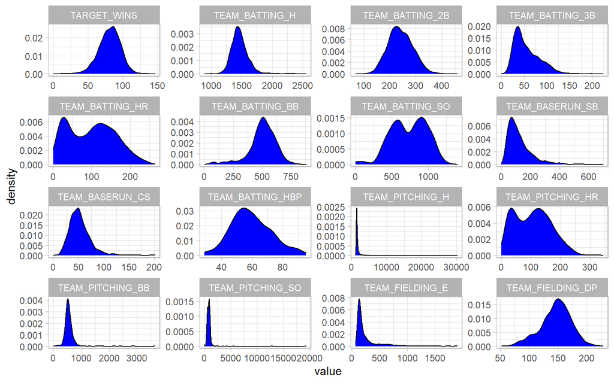

```r
g = melt(train)
ggplot(g, aes(x= value)) +
   geom_density(fill='blue') +
   facet_wrap(~variable, scales = 'free') +
   theme_light()
```

Check for rows with missing values

```r
sum(complete.cases(train))
```

```
## [1] 191
```

Check how many rows with missing values in terms of percentage

```r
sum(complete.cases(train))/(nrow(train)) *100
```

```
## [1] 8.391916
```

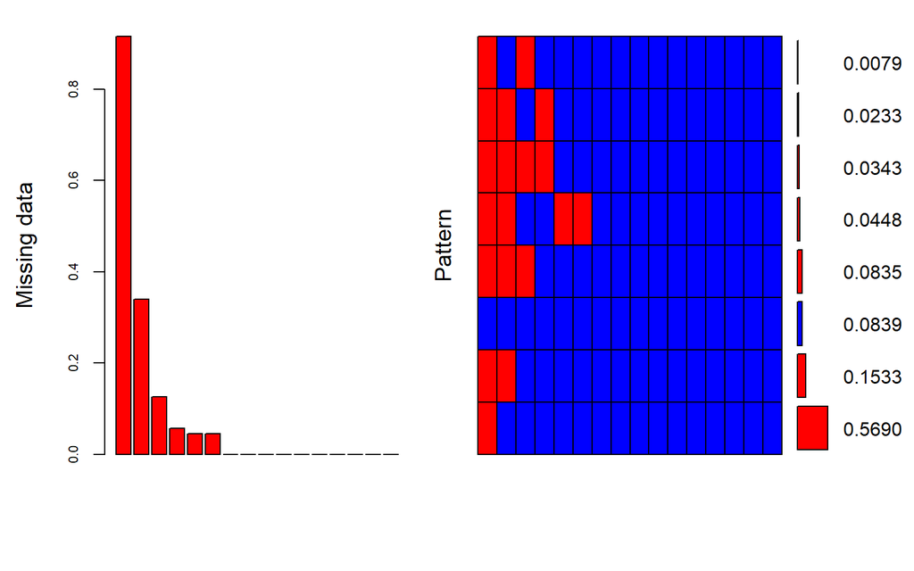

```
##
##  Variables sorted by number of missings:
##          Variable      Count
##  TEAM_BATTING_HBP 0.91608084
##   TEAM_BASERUN_CS 0.33919156
##  TEAM_FIELDING_DP 0.12565905
##   TEAM_BASERUN_SB 0.05755712
##   TEAM_BATTING_SO 0.04481547
##  TEAM_PITCHING_SO 0.04481547
##       TARGET_WINS 0.00000000
##    TEAM_BATTING_H 0.00000000
##   TEAM_BATTING_2B 0.00000000
##   TEAM_BATTING_3B 0.00000000
##   TEAM_BATTING_HR 0.00000000
##   TEAM_BATTING_BB 0.00000000
##   TEAM_PITCHING_H 0.00000000
##  TEAM_PITCHING_HR 0.00000000
##  TEAM_PITCHING_BB 0.00000000
##   TEAM_FIELDING_E 0.00000000
```

```r
missing_plot <- aggr(train, col=c('blue','red'),numbers=TRUE, sortVars=TRUE,labels=names(train), cex.axis=.7,gap=3, ylab=c("Missing data","Pattern"))
```

Six of the variable has missing values.

# Outliers

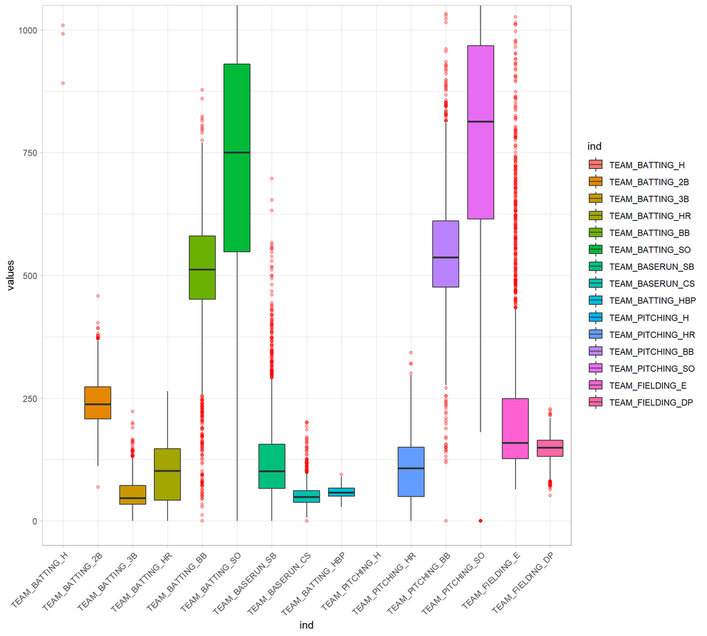

```r
ggplot(stack(train[,-1]), aes(x = ind, y = values, fill=ind)) +
  geom_boxplot(outlier.colour = "red",  outlier.alpha=.3) +
  coord_cartesian(ylim = c(0, 1000)) +
  theme_light()+
  theme(axis.text.x=element_text(angle=45, hjust=1))
```

# Correlations

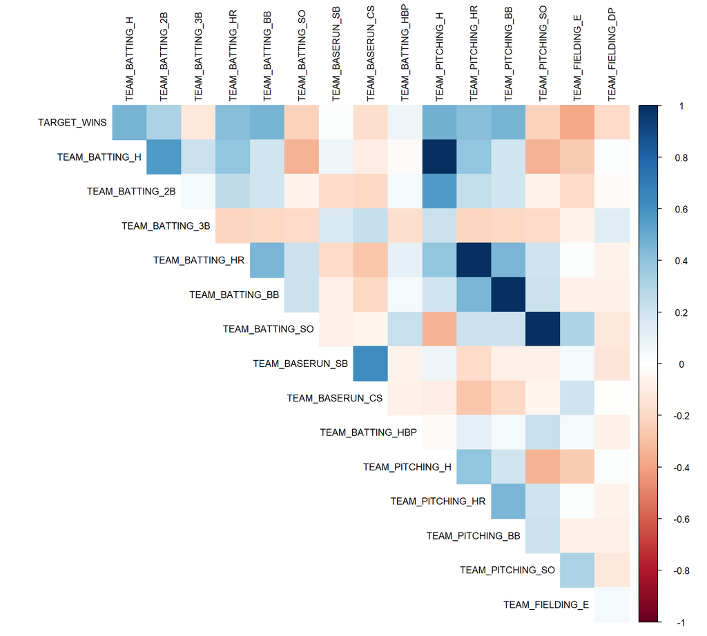

```r
train %>%
  cor(., use = "complete.obs") %>%
  corrplot(., method = "color", type = "upper", tl.col = "black", tl.cex=.8, diag = FALSE)
```

# Data Preparation

Let’s remove TEAM_BATTING_HBP as it has 91.6% missing values

```r
train <- train[-10]
```

We will investigate missing data using naniar package in order to see if we should remove missing data.

https://www.rdocumentation.org/packages/naniar/versions/0.6.0

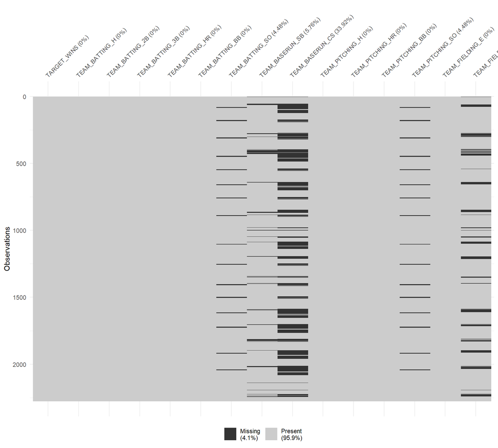

```r
vis_miss(train)
```

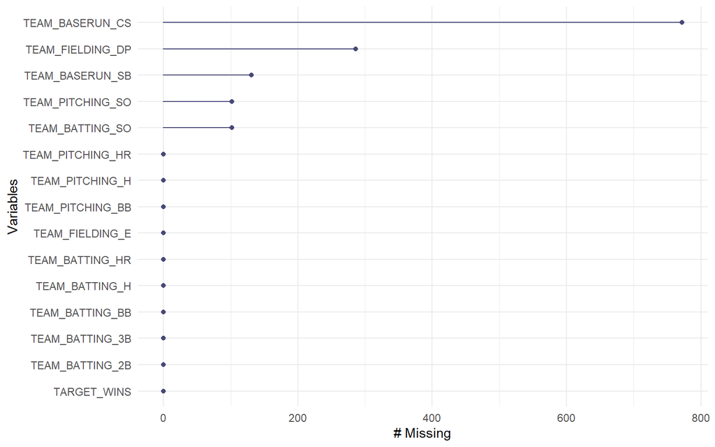

```r
gg_miss_var(train)
```

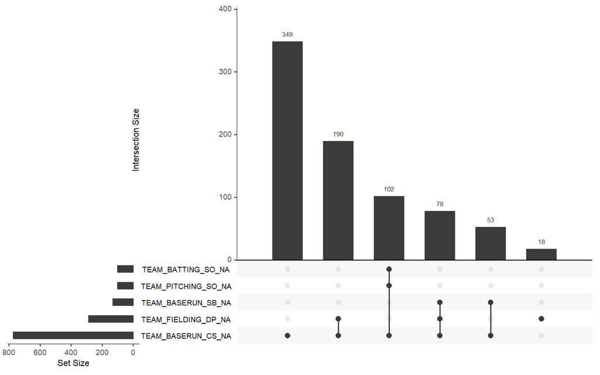

```r
par(mfrow=c(1,2))
gg_miss_upset(train,
              nsets = 5,
              nintersects = NA)
```

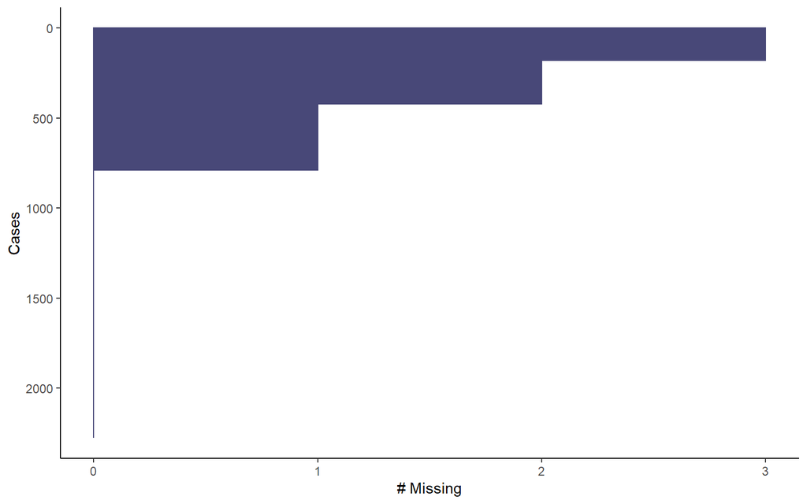

```r
gg_miss_case(train)+
  theme_classic()
```

Let’s replace extreme outliers with median

```r
train1 <- train %>% mutate(TEAM_PITCHING_H = ifelse(TEAM_PITCHING_H > 5000, median(TEAM_PITCHING_H), TEAM_PITCHING_H),
                            TEAM_PITCHING_SO = ifelse(TEAM_PITCHING_SO > 1500, median(TEAM_PITCHING_SO), TEAM_PITCHING_SO))

test1 <- test %>% mutate(TEAM_PITCHING_H = ifelse(TEAM_PITCHING_H > 5000, median(TEAM_PITCHING_H), TEAM_PITCHING_H),
                            TEAM_PITCHING_SO = ifelse(TEAM_PITCHING_SO > 1500, median(TEAM_PITCHING_SO), TEAM_PITCHING_SO))
```

Replace missing values with median

```r
train1[] <- lapply(train1, function(x) ifelse(is.na(x), median(x, na.rm=TRUE), x))
test1[] <- lapply(test1, function(x) ifelse(is.na(x), median(x, na.rm=TRUE), x))
```

```r
# Check missing values
nrow(is.na(train1))
```

```
## [1] 2276
```

```r
nrow(is.na(test1))
```

```
## [1] 259
```

# Model 1

```r
model1 <- lm(TARGET_WINS ~ ., data = train1)

summary(model1)
```

```
##
## Call:
## lm(formula = TARGET_WINS ~ ., data = train1)
##
## Residuals:
##     Min      1Q  Median      3Q     Max
## -48.713  -8.531   0.143   8.327  59.698
##
## Coefficients:
##                    Estimate Std. Error t value Pr(>|t|)
## (Intercept)      19.0215535  5.4173886   3.511 0.000455 ***
## TEAM_BATTING_H    0.0438883  0.0036679  11.966  < 2e-16 ***
## TEAM_BATTING_2B  -0.0241035  0.0091239  -2.642 0.008303 **
## TEAM_BATTING_3B   0.0716540  0.0163857   4.373 1.28e-05 ***
## TEAM_BATTING_HR   0.0907072  0.0286742   3.163 0.001580 **
## TEAM_BATTING_BB   0.0062517  0.0043335   1.443 0.149259
## TEAM_BATTING_SO  -0.0031192  0.0041928  -0.744 0.456990
## TEAM_BASERUN_SB   0.0273493  0.0042676   6.409 1.78e-10 ***
## TEAM_BASERUN_CS  -0.0117669  0.0156684  -0.751 0.452733
## TEAM_PITCHING_H   0.0057303  0.0009149   6.264 4.49e-10 ***
## TEAM_PITCHING_HR -0.0294334  0.0255017  -1.154 0.248551
## TEAM_PITCHING_BB  0.0066266  0.0024329   2.724 0.006505 **
## TEAM_PITCHING_SO -0.0004773  0.0033994  -0.140 0.888359
## TEAM_FIELDING_E  -0.0268879  0.0023285 -11.547  < 2e-16 ***
## TEAM_FIELDING_DP -0.1114890  0.0129614  -8.602  < 2e-16 ***
## ---
## Signif. codes:  0 '***' 0.001 '**' 0.01 '*' 0.05 '.' 0.1 ' ' 1
##
## Residual standard error: 12.99 on 2261 degrees of freedom
## Multiple R-squared:  0.3237, Adjusted R-squared:  0.3195
## F-statistic: 77.29 on 14 and 2261 DF,  p-value: < 2.2e-16
```

Let’s take most significant variables and run the model again to see if we can improve adjusted R-squared

```r
model1 <- lm(TARGET_WINS ~ TEAM_BATTING_H+TEAM_BATTING_3B+TEAM_BASERUN_SB+TEAM_PITCHING_H+TEAM_FIELDING_E+TEAM_FIELDING_DP, data = train1)

summary(model1)
```

```
##
## Call:
## lm(formula = TARGET_WINS ~ TEAM_BATTING_H + TEAM_BATTING_3B +
##     TEAM_BASERUN_SB + TEAM_PITCHING_H + TEAM_FIELDING_E + TEAM_FIELDING_DP,
##     data = train1)
##
## Residuals:
##     Min      1Q  Median      3Q     Max
## -50.709  -8.789   0.058   8.700  58.282
##
## Coefficients:
##                    Estimate Std. Error t value Pr(>|t|)
## (Intercept)      16.6185586  3.2471583   5.118 3.35e-07 ***
## TEAM_BATTING_H    0.0477641  0.0023368  20.440  < 2e-16 ***
## TEAM_BATTING_3B   0.0199208  0.0136987   1.454    0.146
## TEAM_BASERUN_SB   0.0298680  0.0038416   7.775 1.14e-14 ***
## TEAM_PITCHING_H   0.0050447  0.0008686   5.808 7.21e-09 ***
## TEAM_FIELDING_E  -0.0322896  0.0016335 -19.768  < 2e-16 ***
## TEAM_FIELDING_DP -0.0751651  0.0123932  -6.065 1.54e-09 ***
## ---
## Signif. codes:  0 '***' 0.001 '**' 0.01 '*' 0.05 '.' 0.1 ' ' 1
##
## Residual standard error: 13.24 on 2269 degrees of freedom
## Multiple R-squared:  0.2955, Adjusted R-squared:  0.2937
## F-statistic: 158.6 on 6 and 2269 DF,  p-value: < 2.2e-16
```